# CS595 Data Visualization : Assignment 3

Mohit Ram Sharma

2023-03-12

# Loading Data

```r
library(readr)
country_df=read.csv("country_profile.csv")
```

# Data Wrangling

Keeping only the columns required for the assignment and renaming them

```r
library(dplyr)
country_df <- country_df  |> rename('GDP_in_million_current_US_Dollars'=GDP..Gross.domestic.product..million.current.US..)
country_df <- country_df  |> rename('Employment_Agriculture_percent_of_employed'=Employment..Agriculture....of.employed.)
country_df <- country_df  |> rename('Employment_Industry_percent_of_employed'=Employment..Industry....of.employed.)
country_df <- country_df  |> rename('Employment_Services_percent_of_employed'=Employment..Services....of.employed.)
country_df <- country_df  |> rename('Expenditure_on_health_percent_of_GDP'=Health..Total.expenditure....of.GDP.)
country_df <- country_df |> select(country,Region,GDP_in_million_current_US_Dollars,
                                   Employment_Agriculture_percent_of_employed,Employment_Industry_percent_of_employed,
                                  Employment_Services_percent_of_employed,Expenditure_on_health_percent_of_GDP)
```

The variables related to employment details are characters, so we make them numeric. There are some entries in these columns in the form ‘…’, this will convert them to NA.

```r
country_df$Employment_Agriculture_percent_of_employed=as.numeric(country_df$Employment_Agriculture_percent_of_employed)
country_df$Employment_Industry_percent_of_employed=as.numeric(country_df$Employment_Industry_percent_of_employed)
country_df$Employment_Services_percent_of_employed=as.numeric(country_df$Employment_Services_percent_of_employed)
```

The value -99 at a place in our dataset indicates that the data is missing at that place, so we replace all values of -99 by NA.

```r
country_df <- data.frame(lapply(country_df, function(x) ifelse(x == -99, NA, x)))
```

Let’s look at summary of our data to see how many missing values we have in our dataset.

```r
summary(country_df)
```

```
##    country             Region          GDP_in_million_current_US_Dollars
##  Length:229         Length:229         Min.   :      33
##  Class :character   Class :character   1st Qu.:    4987
##  Mode  :character   Mode  :character   Median :   23871
##                                        Mean   :  353896
##                                        3rd Qu.:  174552
##                                        Max.   :18036648
##                                        NA's   :21
##  Employment_Agriculture_percent_of_employed
##  Min.   : 0.20
##  1st Qu.: 4.30
##  Median :17.90
##  Mean   :24.64
##  3rd Qu.:40.15
##  Max.   :91.10
##  NA's   :35
##  Employment_Industry_percent_of_employed
##  Min.   : 2.00
##  1st Qu.:14.10
##  Median :19.20
##  Mean   :18.92
##  3rd Qu.:24.50
##  Max.   :54.10
##  NA's   :34
##  Employment_Services_percent_of_employed Expenditure_on_health_percent_of_GDP
##  Min.   : 6.30                           Min.   : 1.500
##  1st Qu.:43.55                           1st Qu.: 4.825
##  Median :60.50                           Median : 6.350
##  Mean   :56.25                           Mean   : 6.763
##  3rd Qu.:70.20                           3rd Qu.: 8.375
##  Max.   :88.50                           Max.   :17.100
##  NA's   :34                              NA's   :39
```

# Problem 1

### Handling Missing Values

We see that we have 21 missing values in the GDP column. Either we can remove the missing values or we can assign some other values(like mean,median) to these missing values. First let’s look at the density curve of the GDP Distribution.This will give us some idea about what to do with the missing values.

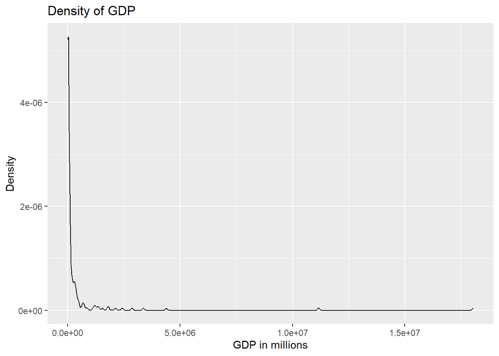

```r
library(ggplot2)
ggplot(country_df,aes(x=GDP_in_million_current_US_Dollars))+geom_density()+
  labs(x="GDP in millions",y="Density",title='Density of GDP')
```

The distribution is positively skewed. So certainly replacing missing values by mean of the GDP is not a good option. Let’s see the how many missing values we have in each region.

```
## # A tibble: 10 × 3
##    Region          Total_NA_values Total__values
##    <chr>                     <int>         <int>
##  1 Caribbean                     4            25
##  2 EasternAfrica                 1            19
##  3 Micronesia                    2             7
##  4 NorthernAfrica                1             7
##  5 NorthernAmerica               1             5
##  6 NorthernEurope                3            13
##  7 Polynesia                     4             9
##  8 SouthAmerica                  2            14
##  9 SouthernEurope                2            16
## 10 WesternAfrica                 1            16
```

We see that except for Polynesia, Northern Europe, Micronesia the percentage of missing values in all other regions is very low. In order to handle the missing values in an efficient manner, If a country has a missing GDP values, we will replace the country’s GDP by mean of the GDP of all the countries in its region.

```r
country_df=country_df %>% mutate(GDP_in_million_current_US_Dollars=ifelse(is.na(GDP_in_million_current_US_Dollars),mean(country_df[country_df["Region"]==Region,]$GDP_in_million_current_US_Dollars,na.rm=TRUE),GDP_in_million_current_US_Dollars))
```

### Data Normalization

We have extreme outliers in the GDP distribution, in order to reduce the effect of the outliers on the boxplot we take log transformation of the data so that the extreme high values are compressed. Also, very often log transformation is used to normalize data coming from a distribution where the distribution is highly skewed or has a long tail. Instead of applying log transformation on the data, we plot the data with log scale.

### The plots

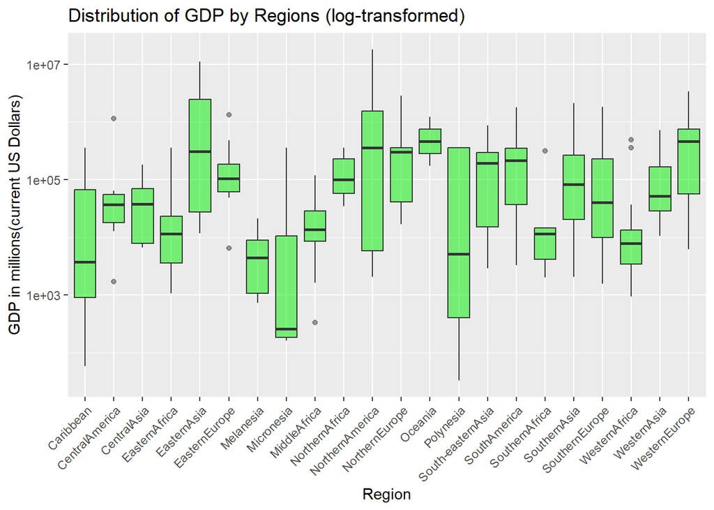

```r
library(ggplot2)
ggplot(data=country_df,aes(x=Region,y=GDP_in_million_current_US_Dollars))+
  geom_boxplot(alpha=0.5,fill="green2")+
scale_y_continuous(trans = "log10")+
  labs(x="Region",y="GDP in millions(current US Dollars)",title="Distribution of GDP by Regions (log-transformed)")+
  theme(axis.text.x = element_text(angle = 45, hjust = 1))
```

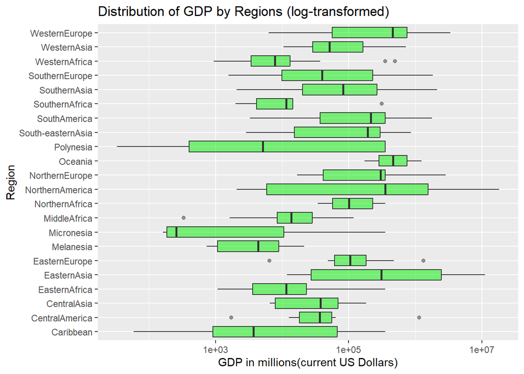

```r
ggplot(data=country_df,aes(x=GDP_in_million_current_US_Dollars,y=Region))+
  geom_boxplot(alpha=0.5,fill="green2")+
scale_x_continuous(trans = "log10")+
  labs(y="Region",x="GDP in millions(current US Dollars)",title="Distribution of GDP by Regions (log-transformed)")
```

### Discuss, whether keeping the Region variable on x-axis or y-axis makes any difference aesthetically :

- Keeping region on the x-axis, creates overlapping of the labels on the x-axis, to solve this issue we need to rotate the text. Keeping region on y-axis, does not create such problem.
- When we have region on the x-axis, the boxes are thick and flat. The boxes are thin and long, when region is on the y-axis, hence in this it is easy to compare distributions of different regions.
- Median values(thick black line inside the box) seems to be more interpretable when region is on the y-axis.

# Question 2

### Adding Continent Variable

```r
asia_regions=c("WesternAsia","CentralAsia","EasternAsia","South-easternAsia","SouthernAsia")
euro_reg=c("WesternEurope","SouthernEurope","NorthernEurope","EasternEurope")
africa_reg=c("WesternAfrica","SouthernAfrica","NorthernAfrica","MiddleAfrica","EasternAfrica")
south_am_reg=("SouthAmerica")
aus_region=c("Oceania","Polynesia","Micronesia","Melanesia")
north_am_reg=c("NorthernAmerica","CentralAmerica","Caribbean")

country_df = country_df |> mutate(Continent=ifelse(Region %in% asia_regions,"Asia",
                                    ifelse(Region %in% euro_reg,"Europe",
                                        ifelse(Region %in% africa_reg,"Africa",
                                              ifelse(Region %in% north_am_reg,"North America",
                                                    ifelse(Region %in% south_am_reg,"South America",
                                                              ifelse(Region %in% aus_region,"Oceania",'NA')))))))
```

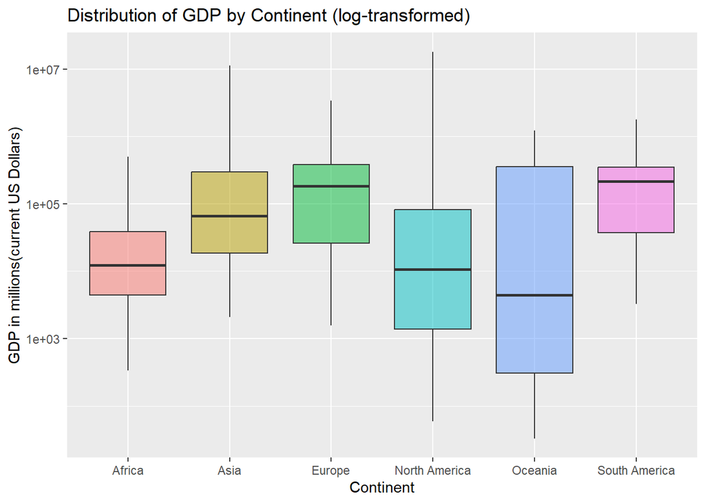

```r
library(ggplot2)
ggplot(data=country_df,aes(x=Continent,y=GDP_in_million_current_US_Dollars,fill=Continent))+
  geom_boxplot(alpha=0.5)+
scale_y_continuous(trans = "log10")+
  labs(x="Continent",y="GDP in millions(current US Dollars)",title="Distribution of GDP by Continent (log-transformed)")+
  guides(fill=FALSE)
```

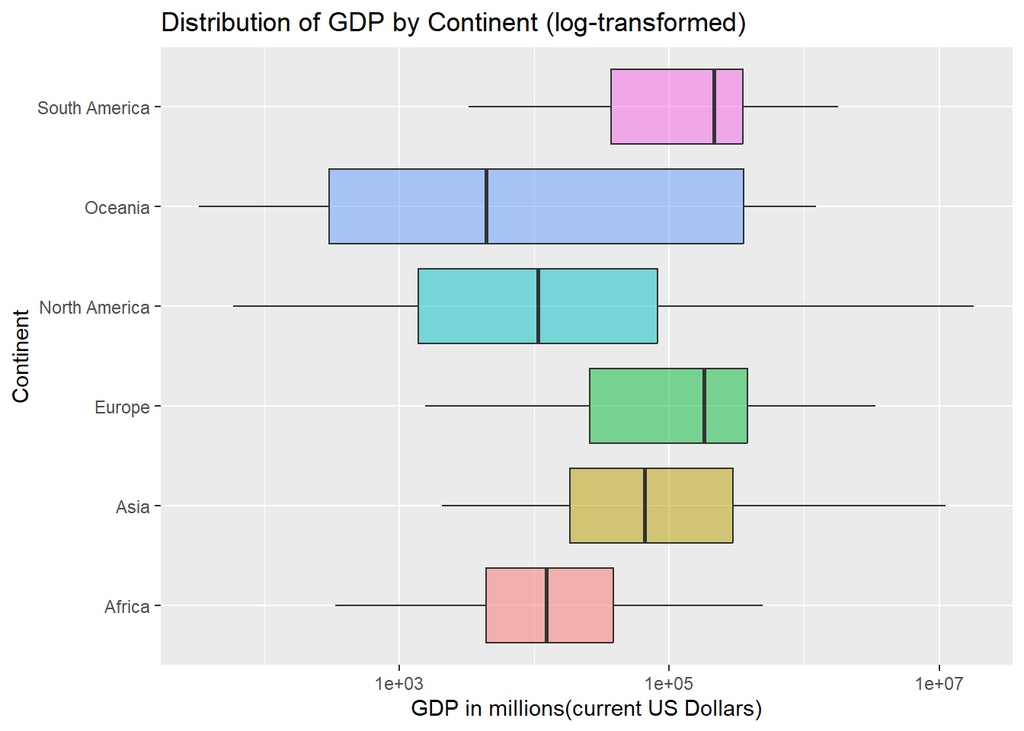

```r
ggplot(data=country_df,aes(x=GDP_in_million_current_US_Dollars,y=Continent,fill=Continent))+
  geom_boxplot(alpha=0.5)+
scale_x_continuous(trans = "log10")+
  labs(y="Continent",x="GDP in millions(current US Dollars)",title="Distribution of GDP by Continent (log-transformed)")+
  guides(fill=FALSE)
```

### Difference between continents and region

- As there are very less number of continents as compared to the regions, so box-plot using continents is more easy to understand,faster to interpret as there are less number of comparisons among the distribution.
- Box-plot using regions is useful if we want to see regions within a continent which have high or low GDP as compared to the rest of the continent. For example, in the continent plot we are not able to see that the Northern America region contributes a very large amount of GDP to the North America continent as compared to the rest of the regions.
- Thus box-plot using continents is fast to understand, easy to interpret but box-plot using regions is more insightful.

# Question 3

### Plots using Faceting

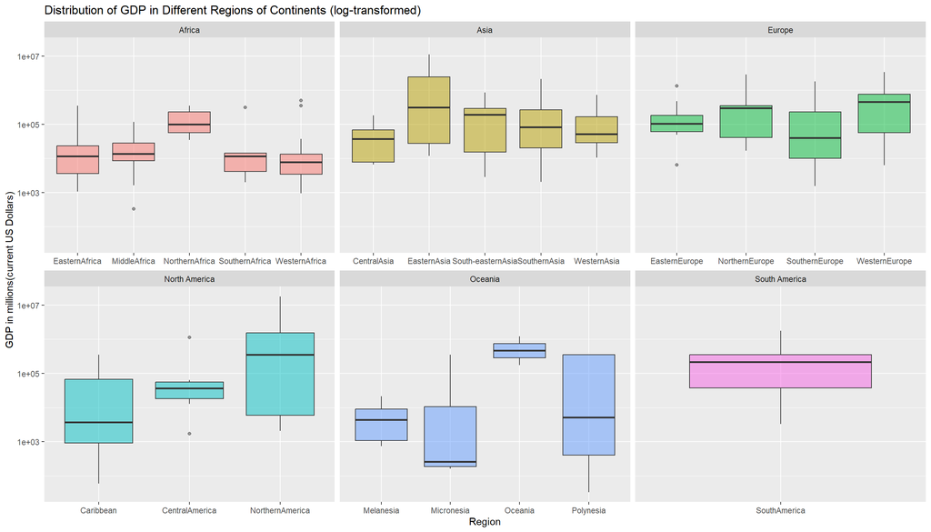

```r
ggplot(data=country_df,aes(x=Region,y=GDP_in_million_current_US_Dollars,fill=Continent))+
  geom_boxplot(alpha=0.5)+
scale_y_continuous(trans = "log10")+
facet_wrap(~Continent,ncol=3,scales = "free_x")+
  labs(x="Region",y="GDP in millions(current US Dollars)",title="Distribution of GDP in Different Regions of Continents (log-transformed)")+guides(fill=FALSE)
```

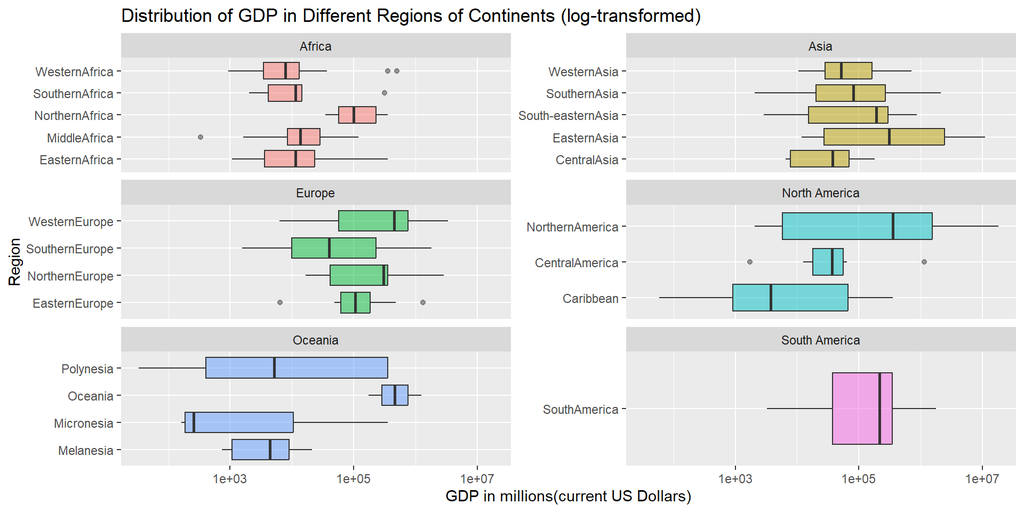

```r
ggplot(data=country_df,aes(x=GDP_in_million_current_US_Dollars,y=Region,fill=Continent))+
  geom_boxplot(alpha=0.5)+
scale_x_continuous(trans = "log10")+
facet_wrap(~Continent,nrow=3,scales="free_y")+
  labs(y="Region",x="GDP in millions(current US Dollars)",title="Distribution of GDP in Different Regions of Continents (log-transformed)")+guides(fill=FALSE)
```

# Question 4

To compare the different continents based on employment in the different sectors, we use stacked bar chart, where bar height will indicate the mean of the employment of a sector in a region. After observing data, I saw that few countries have missing data in all three sectors of the employment. I will remove the countries which have missing values for all the three different sectors as they have no information to give us.

We will also create a long-format dataset to create stacked bar chart.

```r
library(tidyr)
df=country_df |> select(Continent,Employment_Agriculture_percent_of_employed,Employment_Industry_percent_of_employed,
                    Employment_Services_percent_of_employed)
df=df[complete.cases(df),] # Remove rows with NA values
# Group by data to find average expenditure in all regions
df = df |> group_by(Continent) |> summarize(avg_emp_agc = mean(Employment_Agriculture_percent_of_employed),
                                              avg_emp_ind=mean(Employment_Industry_percent_of_employed),
                                              avg_emp_serv=mean(Employment_Services_percent_of_employed))
```

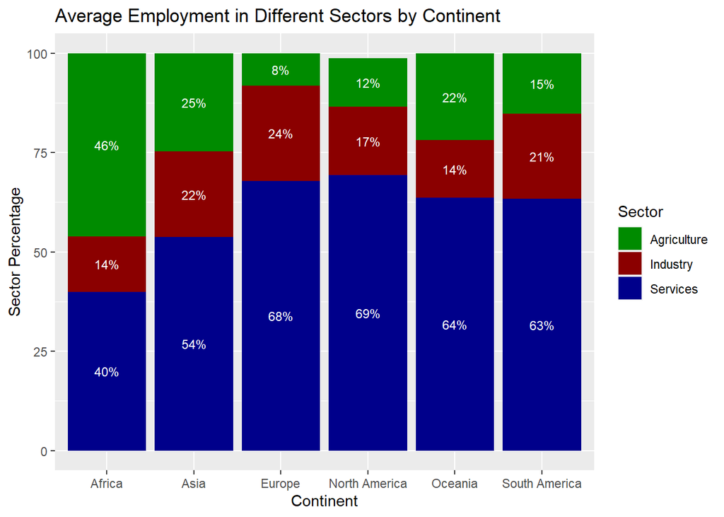

```r
# Convert the data to long format
df_long <- df %>% pivot_longer(cols = c(avg_emp_agc,
                                        avg_emp_ind,
                                       avg_emp_serv), names_to = "Sector", values_to = "Percentage")
# Plot
ggplot(df_long, aes(x = Continent, y = Percentage, fill = Sector)) +
  geom_bar(stat = "identity") +
labs(x="Continent",y="Sector Percentage",title="Average Employment in Different Sectors by Continent") +
  scale_fill_manual(values = c("green4", "red4", "blue4"),labels=c("Agriculture","Industry","Services"))+
  geom_text(aes(label = paste0(round(Percentage), "%")), position = position_stack(vjust = 0.5), size = 3,color="white")
```

# Question 5

We understand the Expenditure on health(percentage of GDP) in different regions of the continents using barplot with error bar. We also do faceting on the continent varibale. We remove the countries which have missing values for expenditure on health.

```r
df= country_df |> select(Region,Continent,Expenditure_on_health_percent_of_GDP)
df= df[complete.cases(df),]
df= df |> group_by(Continent,Region) |>
  summarize(average=mean(Expenditure_on_health_percent_of_GDP),sd=sd(Expenditure_on_health_percent_of_GDP))
```

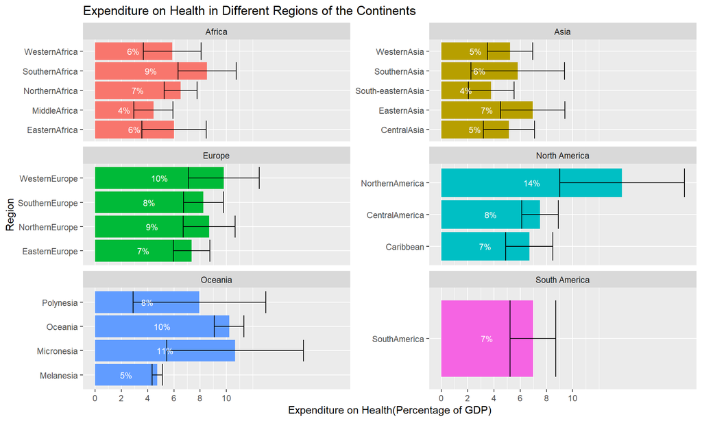

```r
ggplot(df,aes(y=Region,x=average,fill=Continent))+
  geom_bar(stat = "identity")+
  geom_errorbar(aes(xmin = average - sd, xmax = average + sd))+
  facet_wrap(~Continent,nrow=3,scales="free_y")+
  scale_x_continuous(breaks= seq(0,10,2))+guides(fill=FALSE)+
  geom_text(aes(label = paste0(round(average), "%")), position = position_stack(vjust = 0.5), size = 3,color="white")+
  labs(x="Expenditure on Health(Percentage of GDP)",y="Region",title="Expenditure on Health in Different Regions of the Continents")
```

From the plot we can see that, the regions with highest expenditures on health for the different continents are :  
- **Africa:** Souther Africa  
- **Asia:** Eeastern Asia  
- **Europe:** Western Europe  
- **Oceania:** Micronesia  
- **North America:** Northern America  
- **South America**: South America